First Coast Brewery Data Timothy Gibbons/Jacksonville Business Journal 2026-01-28

# Overview

As of January 28, 2026, there are 359 breweries with current licenses in the state of Florida, dating back to Yuengling Brewing Company Of Tampa Inc, which received its license on April 14, 1999.

This data updates automatically when the script is run, but it can be manually downloaded [here](http://www.myfloridalicense.com/dbpr/sto/file_download/extracts/bd4005lic.csv).

On the First Coast[^1], there are 35 breweries with current licenses. The first, Bold City Brewery Llc, was issued its license on an original date of September 08, 2008.

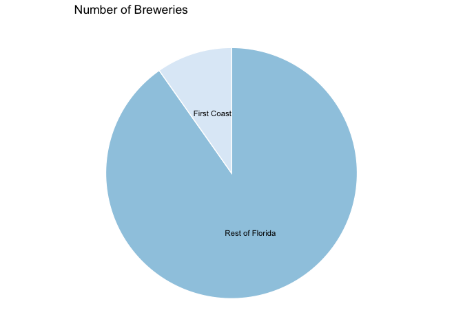

An embeddable version of this chart can be [found here](https://datawrapper.dwcdn.net/9tpfF/1/).

# Growth

The number of breweries across the state has been steadily rising. The most recent brewery to be licensed in Florida is Six Ten Brewing Llc in Tampa, which was permitted on August 26, 2024.

**On the First Coast, the most recent permit was issued to Coquina Coast Brewing Company in Flagler Beach on an effective date of June 25, 2024.**

Here’s how the brewery count across the First Coast has been increasing over the years. Note that this only includes breweries that still have an active license.

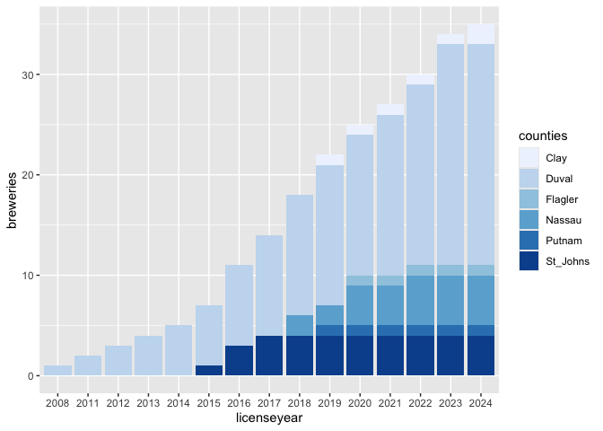

An embeddable version of the chart can be [found here](https://datawrapper.dwcdn.net/WNjo5/1/)

# Sales

The state collects data (for taxation purposes) on *direct* sales by breweries – generally speaking, these are sales made in a taproom. (Unfortunately, overall sales numbers, showing sales through the brewer-wholesaler-retailer system, are not available.)

This data must be downloaded manually; the most recent information was pulled January 28, 2026. The data, which is split between breweries and brewpubs, can be found [here](https://www2.myfloridalicense.com/alcoholic-beverages-and-tobacco/alcoholic-beverages-tobacco-revenue-reporting/).

Breweries across the state obviously saw those sales collapse during the height of the Covid-19 pandemic. Right after the pandemic, the First Coast rebounded more than the state as a whole.

Embeddable versions of the Florida chart [is here](https://datawrapper.dwcdn.net/Mkh3c/1/) and of the First Coast chart [is here](https://datawrapper.dwcdn.net/Mirvi/1/)

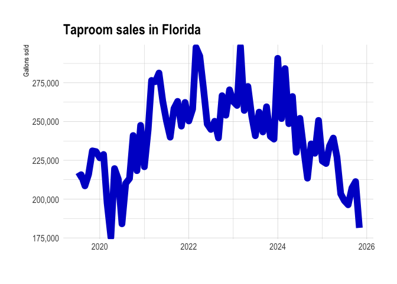

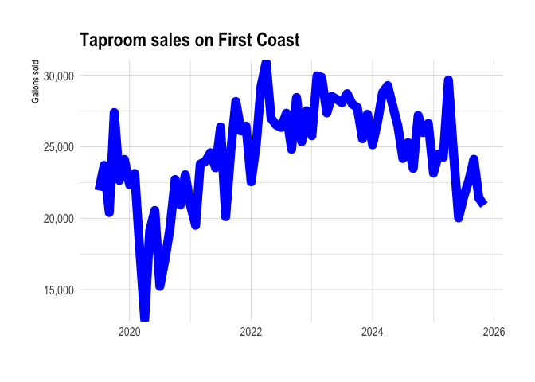

The brewery in Florida that has sold the most beer directly to consumers in 2023 is Anheuser Busch, which has sold 82,826.74 gallons.

Among First Coast craft breweries — excluding Budweiser — Wicked Barley’s taproom moved the largest amount of beer, selling 37,752.86 gallons directly to consumers.

In the latest 12 months of data – from December 2024 to November 2025 – the 34 breweries and brewpubs in the area that reported sales moved 283,407.9 gallons of beer.

[^1]: Baker, Clay, Duval, Flagler, Nassau, Putnam and St. Johns counties